# Skrypty geoprzetwarzania

Przetwarzanie danych rastrowych

Author

Krzysztof Dyba

```r
library("terra")
```

# Generowanie danych

Na poprzednich zajęciach wykorzystaliśmy funkcję `rast()` do wczytania danych rastrowych, niemniej posiada ona więcej zastosowań. Na przykład można użyć ją do konwersji (macierz -> raster) czy wygenerowania nowego rastra z zadanymi parametrami. W przypadku tworzenia nowego rastra można zdefiniować m. in. liczbę wierszy, kolumn i warstw, zakres przestrzennych, układ współrzędnych czy rozdzielczość. Zdefiniujmy “szablon” bez wartości:

```r
raster = rast(nrows = 10, ncols = 20, nlyrs = 1,
              xmin = -180, xmax = 180, ymin = -90, ymax = 90,
              crs = "EPSG:4326")
raster
```

```
class       : SpatRaster
dimensions  : 10, 20, 1  (nrow, ncol, nlyr)
resolution  : 18, 18  (x, y)
extent      : -180, 180, -90, 90  (xmin, xmax, ymin, ymax)
coord. ref. : lon/lat WGS 84 (EPSG:4326)
```

Funkcja `rast()` przyjmuje argument `vals`, który zostawiliśmy pusty, w związku z czym stworzonemu rastrowi nie zostały przypisane żadne wartości. Możemy to potwierdzić za pomocą funkcji `hasValues()`.

```r
hasValues(raster)
```

```
[1] FALSE
```

De facto, oznacza to, że stworzyliśmy jedynie metadane rastra (tj. “szablon”). Jeśli chcemy go wypełnić, to musimy przypisać / wygenerować tyle wartości z ilu komórek składa się raster.

```r
n = ncell(raster) # liczba komórek rastra
wartosci = rnorm(n, mean = 0, sd = 1) # wylosuj wartości z rozkładu normalnego
head(wartosci) # wyświetl 6 pierwszych wylosowanych wartości
```

```
[1] -1.2688410  0.1198025 -0.4345546 -0.3078473  1.2053923  0.8050789
```

```r
# hist(wartosci) # histogram
```

Teraz przypiszmy wygenerowane wartości do `raster` za pomocą funkcji `values()`.

```r
values(raster) = wartosci
raster
```

```
class       : SpatRaster
dimensions  : 10, 20, 1  (nrow, ncol, nlyr)
resolution  : 18, 18  (x, y)
extent      : -180, 180, -90, 90  (xmin, xmax, ymin, ymax)
coord. ref. : lon/lat WGS 84 (EPSG:4326)
source(s)   : memory
name        :     lyr.1
min value   : -2.576067
max value   :  2.811464
```

Wyświetlmy obiekt `raster`. Dodatkowo możemy wyświetlić wartości komórek jako etykiety używając funkcji `text()` z argumentami określającymi liczbę znaków (`digits`) oraz rozmiar tekstu (`cex`).

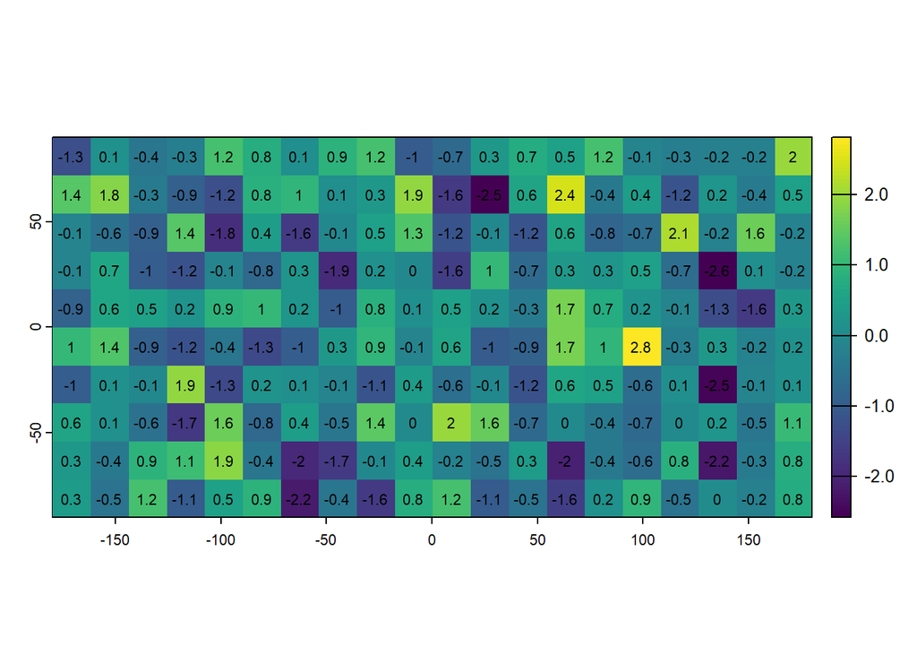

```r
plot(raster)
text(raster, digits = 1, cex = 0.7)
```

# Algebra rastrów

Na rastrach można wykonywać standardowe działania algebraiczne, operacje logiczne oraz funkcje matematyczne.

```r
r1 = sqrt(raster + 10)
r1
```

```
class       : SpatRaster
dimensions  : 10, 20, 1  (nrow, ncol, nlyr)
resolution  : 18, 18  (x, y)
extent      : -180, 180, -90, 90  (xmin, xmax, ymin, ymax)
coord. ref. : lon/lat WGS 84 (EPSG:4326)
source(s)   : memory
name        :   lyr.1
min value   : 2.72469
max value   : 3.57931
```

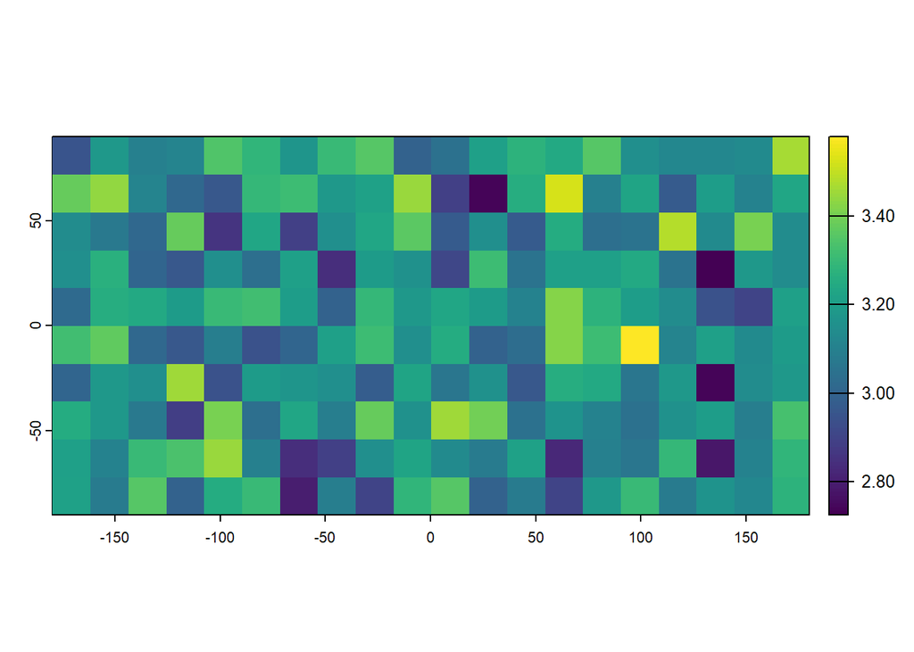

```r
plot(r1)
```

```r
r2 = abs(raster - r1)
r2
```

```
class       : SpatRaster
dimensions  : 10, 20, 1  (nrow, ncol, nlyr)
resolution  : 18, 18  (x, y)
extent      : -180, 180, -90, 90  (xmin, xmax, ymin, ymax)
coord. ref. : lon/lat WGS 84 (EPSG:4326)
source(s)   : memory
name        :     lyr.1
min value   : 0.7678469
max value   : 5.3007566
```

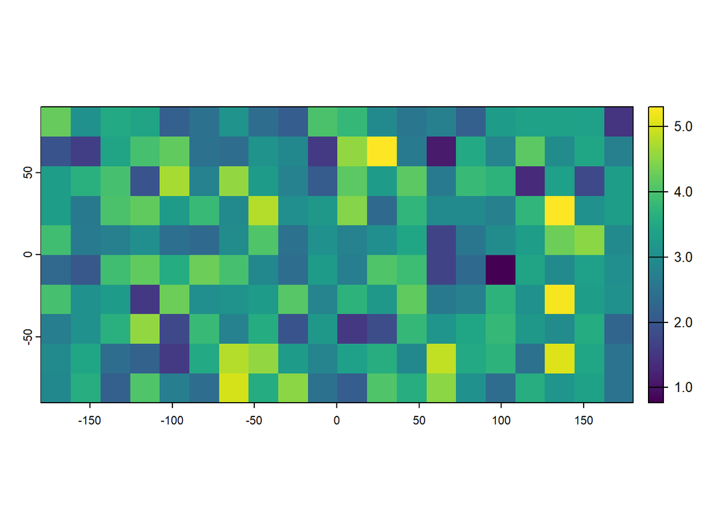

```r
plot(r2)
```

```r
r3 = raster < 0 # operacja logiczna
r3
```

```
class       : SpatRaster
dimensions  : 10, 20, 1  (nrow, ncol, nlyr)
resolution  : 18, 18  (x, y)
extent      : -180, 180, -90, 90  (xmin, xmax, ymin, ymax)
coord. ref. : lon/lat WGS 84 (EPSG:4326)
source(s)   : memory
name        : lyr.1
min value   : FALSE
max value   :  TRUE
```

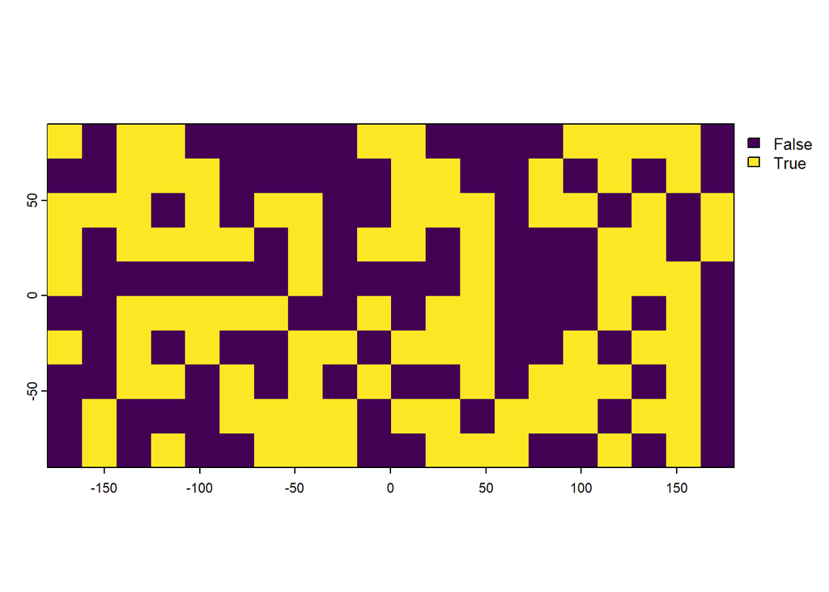

```r
plot(r3)
```

# Operacje

## Docinanie

Nadmierny zasięg rastra wykraczający poza obszar analizy można dociąć za pomocą funkcji `crop()` używając innego rastra (*SpatRaster*), wektora (*SpatVector*) lub zasięgu zdefiniowanego przy użyciu współrzędnych (*SpatExtent*). W poniższym przykładzie wyznaczymy zasięg używając funkcji `ext()`.

```r
zasieg = ext(-100, 100, -50, 50) # xmin, xmax, ymin, ymax
r = crop(raster, zasieg)
r
```

```
class       : SpatRaster
dimensions  : 6, 12, 1  (nrow, ncol, nlyr)
resolution  : 18, 18  (x, y)
extent      : -108, 108, -54, 54  (xmin, xmax, ymin, ymax)
coord. ref. : lon/lat WGS 84 (EPSG:4326)
source(s)   : memory
name        :     lyr.1
min value   : -1.922168
max value   :  2.811464
```

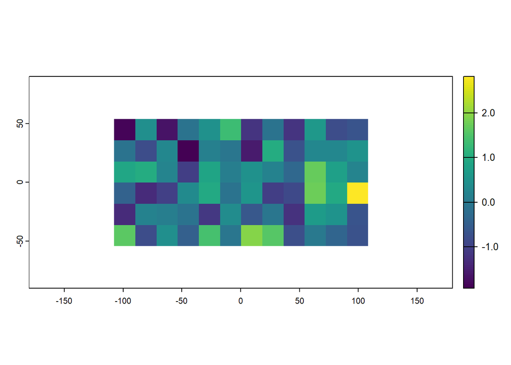

```r
plot(r, ext = ext(raster)) # porównaj z oryginalnym zasięgiem
```

Należy zauważyć, że zasięg dociętego rastra może różnić się od oczekiwanego, ponieważ zwracane są pełne komórki w wierszach i kolumnach.

## Zmiana rozdzielczości

Rozdzielczość przestrzenną rastra można zmienić za pomocą trzech funkcji:

- `disagg()` (zwiększa rozdzielczość, czyli komórki stają się mniejsze)
- `aggregate()` (zmniejsza rozdzielczość, czyli komórki stają się większe)
- `resample()` (przepróbkowanie do zdefiniowanej siatki)

Pierwsze dwie funkcje wymagają podanie współczynnika agregacji, natomiast ostatnia wymieniona funkcja wymaga wskazania rastra z oczekiwaną geometrią. W przypadku funkcji `disagg()` dostępne są dwie metody, tj. interpolacji najbliższego sąsiada (`near`) oraz dwuliniowej (`bilinear`). Ta pierwsza stosowana jest najczęściej w przypadku danych kategorycznych. Zauważ również, że zastosowanie tej metody powoduje podział komórki na mniejsze części, co nie wpływa na efekt wizualizacji.

```r
r1 = disagg(raster, fact = 2, method = "bilinear")
r2 = aggregate(raster, fact = 2, fun = "mean")
```

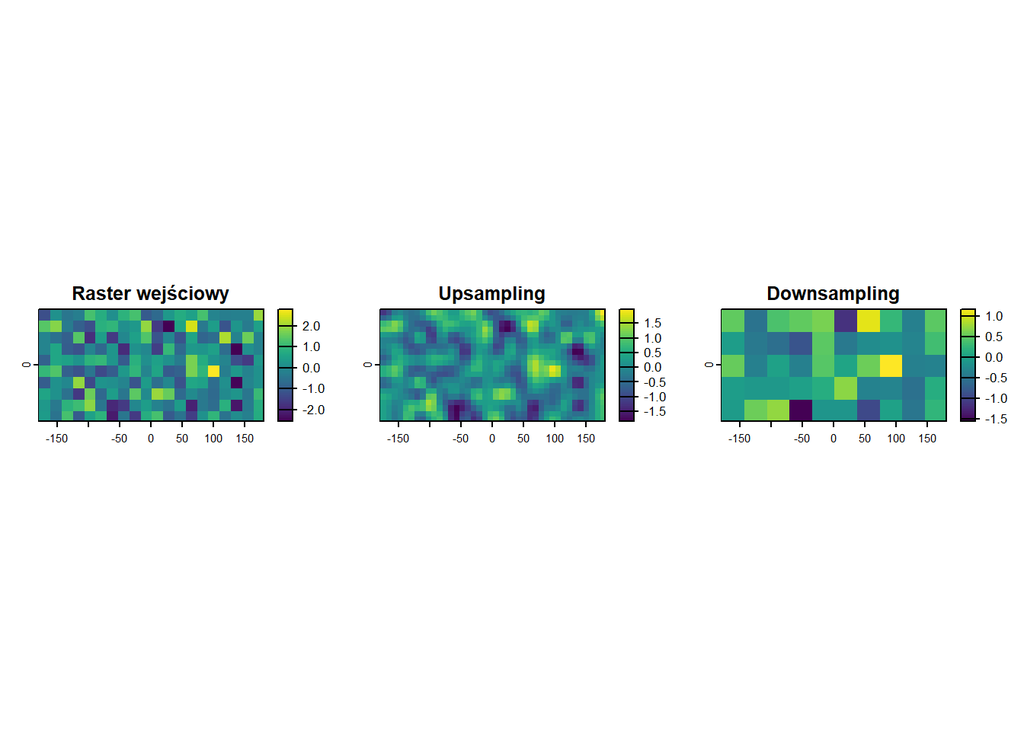

```r
par(mfrow = c(1, 3)) # wyświetl 3 rastry obok siebie
plot(raster, main = "Raster wejściowy")
plot(r1, main = "Upsampling")
plot(r2, main = "Downsampling")
```

Rozdzielczość rastrów można także sprawdzić za pomocą funkcji `res()`. Sprawdźmy jeszcze jak zastosować funkcję `resample()` w praktyce.

```r
szablon = rast(nrows = 20, ncols = 40,
               xmin = -180, xmax = 180, ymin = -90, ymax = 90)
r3 = resample(raster, szablon, method = "bilinear")
```

## Reprojekcja

Do transformacji przestrzennego układu współrzędnych służy funkcja `project()`. Tak jak w przypadku poprzednich funkcji można wykorzystać różne metody interpolacji. Przetransformujmy nasz aktualny układ `EPSG:4326` wyrażony w stopniach do odwzorowania Mollweidego (`+proj=moll`) wyrażonego w metrach.

```r
r_moll = project(raster, "+proj=moll", method = "bilinear")
r_moll
```

```
class       : SpatRaster
dimensions  : 22, 45, 1  (nrow, ncol, nlyr)
resolution  : 788849.2, 806777.6  (x, y)
extent      : -18040096, 17458119, -8729059, 9020048  (xmin, xmax, ymin, ymax)
coord. ref. : +proj=moll +lon_0=0 +x_0=0 +y_0=0 +datum=WGS84 +units=m +no_defs
source(s)   : memory
name        :     lyr.1
min value   : -2.040229
max value   :  2.567302
```

Porównajmy otrzymany raster z oryginalnym.

```r
raster
```

```
class       : SpatRaster
dimensions  : 10, 20, 1  (nrow, ncol, nlyr)
resolution  : 18, 18  (x, y)
extent      : -180, 180, -90, 90  (xmin, xmax, ymin, ymax)
coord. ref. : lon/lat WGS 84 (EPSG:4326)
source(s)   : memory
name        :     lyr.1
min value   : -2.576067
max value   :  2.811464
```

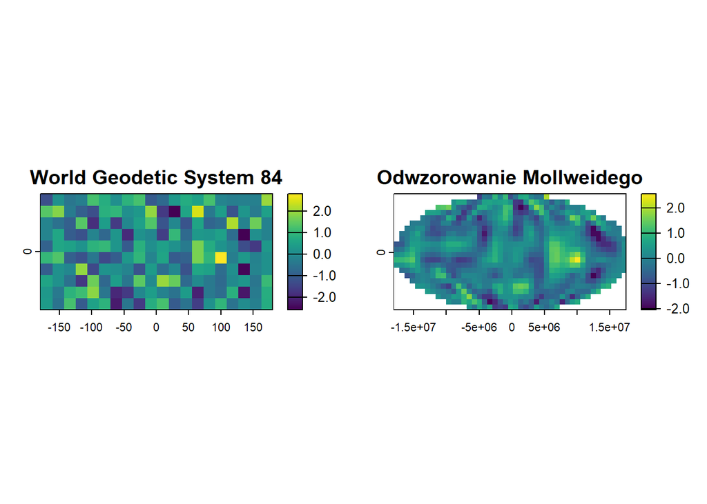

```r
par(mfrow = c(1, 2))
plot(raster, main = "World Geodetic System 84")
plot(r_moll, main = "Odwzorowanie Mollweidego")
```

Jeśli posiadasz dane rastrowe i wektorowe w różnych układach współrzędnych, to zalecana jest reprojekcja danych wektorowych z dwóch powodów:

- jest szybsza
- jest odwracalna (transformacja odbywa się bez utraty precyzji)

## Statystyki globalne

Wyliczenie statystyk komórek warstwy rastrowej można wykonać za pomocą funkcji `global()`. Dla przykładu:

```r
# data.frame() łączy poniższe obiekty do jednego
data.frame(
  global(raster, "sum"),
  global(raster, "mean"),
  global(raster, "sd")
)
```

```
           sum       mean       sd
lyr.1 -5.01682 -0.0250841 1.008901
```

## Statystyki strefowe

Jeśli posiadamy dwa rastry, tj. pierwszy numeryczny, a drugi kategoryczny (określający strefy), to możemy wyliczyć statystyki strefowe. Najpierw wykorzystajmy funkcje `sample()` do wygenerowania kategorii oznaczonych numerami od 1 do 3 (w rzeczywistej analizie mogą one reprezentować, np. zbiornik wodny, las i strefę zabudowaną). Musimy ustawić argument `replace = TRUE`, aby wykonać losowanie ze zwracaniem.

```r
kategorie = sample(1:3, size = ncell(raster), replace = TRUE)
head(kategorie)
```

```
[1] 1 1 3 1 1 3
```

Następnie kopiujemy raster wejściowy `raster` wykorzystując funkcję `rast` zastępując przy tym jego wartości `vals = kategorie` i nowy raster nazywamy `strefy`.

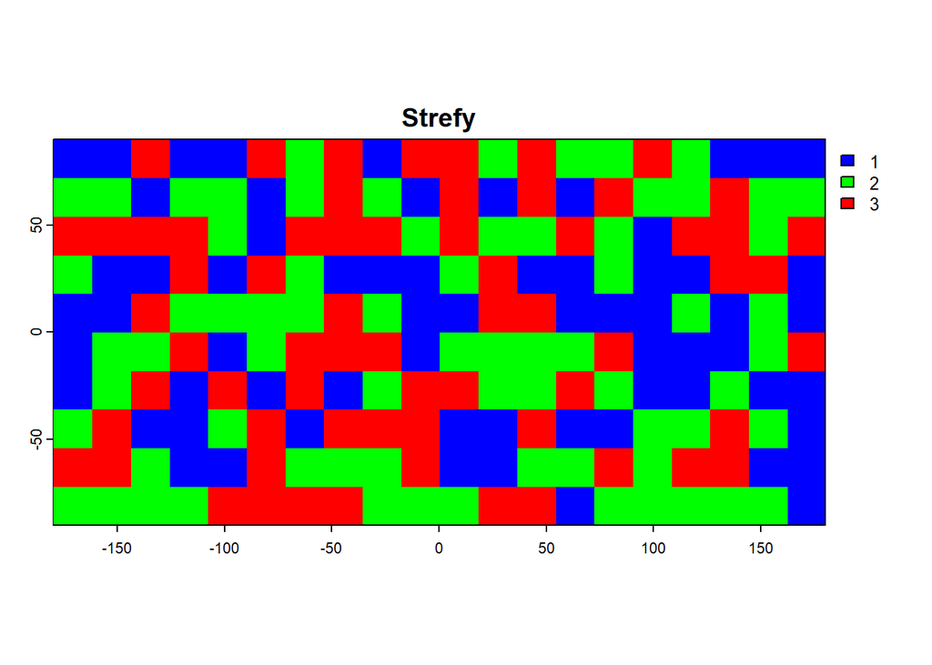

```r
strefy = rast(raster, vals = kategorie)
plot(strefy, main = "Strefy", col = c("blue", "green", "red"))
```

Teraz możemy obliczyć statystyki strefowe.

```r
stat_strefy = zonal(raster, strefy, fun = "mean")
stat_strefy
```

```
  lyr.1     lyr.1.1
1     1  0.17900784
2     2 -0.07868728
3     3 -0.17144954
```

## Reklasyfikacja

Reklasyfikacja wartości rastra możliwa jest za pomocą funkcji `classify()`. Załóżmy, że chcemy wszystkie wartości poniżej 0 zamienić na brakujące wartości (`NA`), a wszystkie wartości powyżej 0 zamienić na 10. W tym celu musimy stworzyć tabelę klasyfikacyjną składającą się z trzech kolumn:

1. dolny przedział wartości
2. górny przedział wartości
3. nowa wartość

Tabelę najprościej stworzyć definiując uprzednio wektor i następnie transformując go do macierzy.

```r
# wektor
tabela = c(
  -Inf, 0, NA,
  0, Inf, 10
)
# zamiana wektora na macierz
tabela = matrix(tabela, ncol = 3, byrow = TRUE)
tabela
```

```
     [,1] [,2] [,3]
[1,] -Inf    0   NA
[2,]    0  Inf   10
```

Teraz przeprowadźmy reklasyfikację.

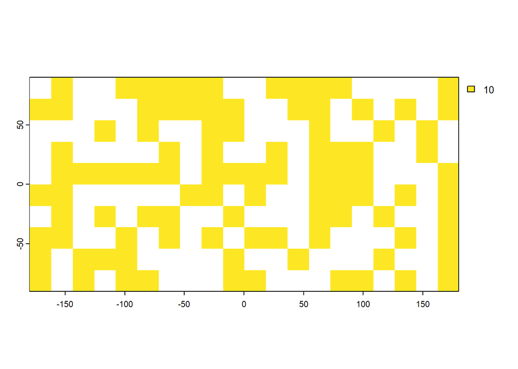

```r
reklasyfikacja = classify(raster, tabela)
plot(reklasyfikacja)
```

Istnieje również prostsza alternatywa w postaci `subst()` ukierunkowana na zastępowanie wartości.

## Okno ruchome

Ostatnią omawianą funkcją jest `focal()` służącą do obliczania wartości na podstawie sąsiadujących komórek rastra w ruchomym oknie. Można zdefiniować dowolny kształt sąsiedztwa (np. prostokąt, koło) oraz nadać komórkom odpowiednie wagi. Zazwyczaj niniejszą funkcję wykorzystuje się do wygładzania danych numerycznych za pomocą średniej czy mediany oraz danych kategorycznych za pomocą mody.

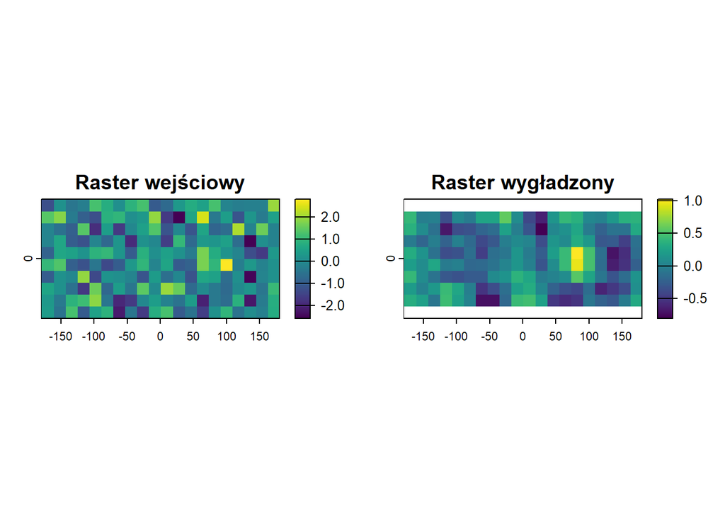

```r
r = focal(raster, w = 3, fun = "mean")
par(mfrow = c(1, 2))
plot(raster, main = "Raster wejściowy")
plot(r, main = "Raster wygładzony")
```

Omówiliśmy tylko podstawowe i najczęściej stosowane funkcje do przetwarzania danych rastrowych. Pakiet **terra** oferuje ich zdecydowanie więcej (sprawdź dokumentację).

# Zadanie

3. Z portalu [OpenTopography](https://opentopography.org/) pobierz numeryczny model pokrycia terenu (np. NASADEM lub SRTM) dla małego fragmentu Polski i wykonaj następujące czynności:
- sprawdź metadane pobranego rastra i wyświetl go
- transformuj układ współrzędnych do `EPSG:2180`
- przytnij raster do zmniejszonego zasięgu przestrzennego
- wygładź wartości używając średniej arytmetycznej w oknie ruchomym
- oblicz statystyki rastra, tj. wartość minimalna i maksymalna, średnia oraz odchylenie standardowe
- zapisz raster na dysku z kompresją LZW